# SEÑALES PARES E IMPARES

## SISTEMAS Y SEÑALES

### Ingenieria de Telecomunicaciones

### Universidad Pontificia Bolivariana

### Por: Jose R. Zapata - https://joserzapata.github.io/

**joser.zapata@upb.edu.co**

```python
# Script para ver y ocultar el codigo del jupyter
from IPython.display import HTML

HTML('''<script>
  function code_toggle() {
    if (code_shown){
      $('div.input').hide('500');
      $('#toggleButton').val('Ver el Codigo de Python')
    } else {
      $('div.input').show('500');
      $('#toggleButton').val('Ocultar el Codigo')
    }
    code_shown = !code_shown
  }

  $( document ).ready(function(){
    code_shown=false;
    $('div.input').hide()
  });
</script>
<form action="javascript:code_toggle()">
<input type="submit" id="toggleButton" value="Ver el Codigo de Python"></form>''')
```

# Señales Pares

Una señal $x(t)$ ó $x[n]$ es par si se «refleja» en el eje vertical u ordenadas.

$x(t) = x(-t)$

$x[n] = x[-n]$

La señal tiene los mismos valores para el lado positivo o negativo de $|t|$.

Es como si se aplicara el valor absoluto de t antes de hacerlo en la ecuación.

```python
import numpy as np
import matplotlib.pyplot as plt
plt.style.use('bmh') # estilo de las graficas
%matplotlib inline



# parámetros
T = 2*np.pi
m = 1 #periodos para la gráfica
t0 = -m*T #usa lado negativo de abscisas
n = 100
```

## Ejemplo función par

Una señal par conocida es $\large cos(\omega t)$

Para observar mejor, se marcará el área que genera la función dentro de un periodo centrado en el origen.

Se marcara el periodo comprendido en: $[-T/2,T/2]$, sombreando alrededor de $t=0$

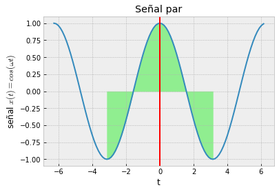

```python
# PROCEDIMIENTO
# vector de tiempo
tn = -t0  # completa el reflejo positivo
dt = (tn-t0)/n
t = np.arange(t0,tn,dt)

# Señal
f = 1/T
w = 2*np.pi*f
senalpar = np.cos(w*t)

# marcar un periodo en [desde, hasta)
desde = -T/2
hasta = desde + T + dt
tperiodo = np.arange(desde,hasta,dt)
periodopar = np.cos(w*tperiodo)

# Gráficas
plt.plot(t,senalpar)
plt.xlabel('t')
plt.ylabel('señal $x(t) = cos(\omega t)$')
plt.grid(True)

# marcar un periodo
plt.title('Señal par')
plt.fill_between(tperiodo,0, periodopar,color='lightgreen')
plt.axvline(x=0, color='red')
plt.show()
```

# Señales Impares

Una señal $x(t)$ ó $x[n]$ es impar si se cumple que:

$x(t) = -x(-t)$

$x[n] = -x[-n]$

Una señal impar debe ser necesariamente 0 en $t=0$ o $n=0$.

## Ejemplo función impar

Una señal impar conocida es $\large sin(\omega t)$

Para observar mejor, se marcará el area que genera la función dentro de un periodo centrado en el origen.

Como el eje t ya fué generado en el ejercicio anterior, se continúa con la generación de la gráfica.

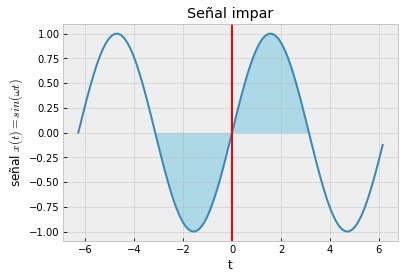

```python
# señal
senalimpar = np.sin(w*t)

# marcar un periodo
periodoimpar = np.sin(w*tperiodo)

# SALIDA
# Gráficas
plt.plot(t,senalimpar)
plt.xlabel('t')
plt.ylabel('señal $x(t) = sin(\omega t)$')
plt.grid(True)

# marcar un periodo
plt.title('Señal impar')
plt.fill_between(tperiodo,0, periodoimpar,color='lightblue')
plt.axvline(x=0, color='red')
plt.show()
```

Cualquier señal se puede separar en la suma de 2 señales, una de las cuales es par y la otra impar

\begin{equation} \large Par|x(t)|= \frac{1}{2}[x(t)+x(-t)] \end{equation}

\begin{equation} \large Impar|x(t)|= \frac{1}{2}[x(t)-x(-t)] \end{equation}

# Ejercicios

probar Si las siguientes funciones son pares o impares

- $\large t$
- $\large |t|$
- $\large t^2$
- $\large t^3$
- $\large |-e^t|$

# REFERENCIAS

Oppenheim Seccion 1.2.3

**Phd. Jose R. Zapata**

- https://joserzapata.github.io/
- https://twitter.com/joserzapata
- joser.zapata@upb.edu.co